### What is multiple files comparison?

User is able to upload up to three proteomics experiment results to perform comparative analysis. The QC panel is similar to that of single file upload and user is able to visualize up to three results as volcano and scatter plots, search for protein of interest using its corresponding gene name, and search for and/or remove group of genes belonging to certain protein families. Multiple files comparison features require minimum of two input files. The marker colors can be changed using the drop down options titled ‘Color selection for markers.’ Genoppi interface with three sample files loaded is shown in figure below.

[figure not shown]

### Protein comparison

FDR, pvalue and logFC controllers are generated for each uploaded proteomics data in the ‘Protein Comparison’ tab as shown below.

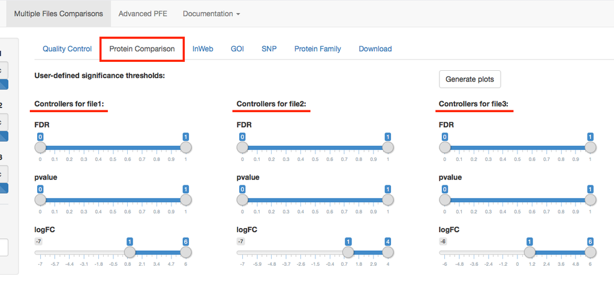

After setting the significance thresholds, clicking on the ‘Generate plots’ button will generate comparative volcano plots of all user-uploaded data. The comparison is performed using protein identifiers as HGNC symbols and the color scheme are as explained below.

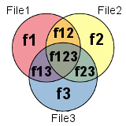

**f1**: marked in red are proteins unique to file1

**f2**: marked in yellow are proteins unique to file2

**f3**: marked in blue are proteins unique to file3

**f12**: marked in orange are proteins identified in both file1 and file2

**f13**: marked in purple are proteins identified in both file1 and file3

**f23**: marked in green are proteins identified in both file2 and file3

**f123**: marked in gray are proteins identified in file1, file2 and file3

The volcano plots show user’s original uploaded data as background markers in white/gray and colored markers belonging to different groups as explained above (i.e. unique to file1, in both file2 and file3 etc.)

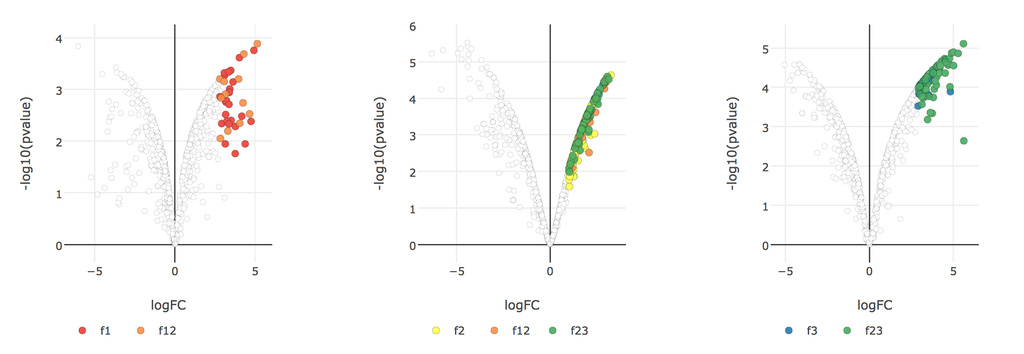

To easily identify what proteins and how many of them are unique to each group, Venn diagram shows how many proteins and the table lists the proteins using HGNC symbols unique to each group.

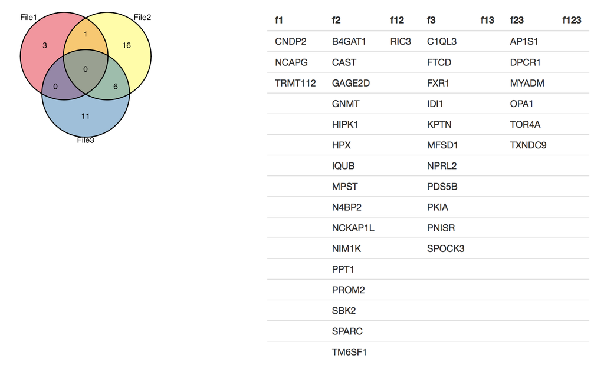

### Overlaying with genetics and identifying protein families

The integrative analysis using genetics data and identifying protein families is performed in similar method as that of the single file analysis. Please refer to the documentation on single file for detailed description.